# 1_Cleaning_Processing_EDA

## Project Overall Objects

This notebook file would approach and achieve the objects highlighted in **black**. Those in *grey* would be accomplished in later analysis.

- Clean dirty log data and transform it for analytics.
- Exploratory Data Analysis (EDA)
- Find the conversion rate of users, identify key factors that bottleneck the conversion rate.
- Propose any hypothesis and set up experiments for testing.
- Build machine learning models to predict user behaviors, including but not limited to signup, churn, etc.
- Discover interesting insights in the dataset and suggest how to improve the user signup rate.

This notebook file is meant to facilitate the analyst to dive deep into the dataset, given the results from Summary_Statistics. Some of the analysis might appear to be repetitive and or similar to what has been achieved in 0_Summary_Statistics, but the analysis are in fact being applied on different parts/keys of the whole dataset.

The previous step is to give the analyst a quick understanding of the overall performance of the given dataset by looking into the distribution of data within each type. In this phase, we would be doing real data cleaning, and EDA to transform the dataset into one that's more readable and understandable for members in other teams.

The outpuf of this notebook is a well-cleaned dataset, after EDA, with most of the originally features/keys remaining, together with a conversion rate chart of different events.

```python
import pandas as pd
import json
import os
import datetime
import numpy as np
import warnings
warnings.filterwarnings('ignore')
```

```python
def to_date(epoch):
    return datetime.datetime.fromtimestamp(epoch/1000).strftime("%Y-%m-%d")
# first convert from milliseconds to seconds, and then convert format from time stamp
```

```python
# this finds our txt files
filename = "data/UBA_sample_data.txt"
data = []
for line in open(filename, 'r'):
    data.append(json.loads(line))
```

```python
# total number of rows
len(data)
```

```
75092
```

hash: change from browser and cookie id to protect user privacy, randomnized id, can be used to conduct unbiased experiments/tran test split

```python
# here I define my pandas Dataframe with the columns I want to get from the text
# If any of the following features are out of your interest
# simple just remove the array creation here, and the value assignment in the following cell.
nocache = []
dist_id = []
event = []

browser = []
browser_v = []
ip = []
is_fd = []
is_ft = []
latest_r = []
latest_rh = []
latest_ch = []
latest_utm_campaign = []
latest_utm_content = []
latest_utm_m = []
latest_utm_s = []
latest_utm_t = []
model = []
os = []
os_version = []
screen_h = []
screen_w = []
session_r = []
session_rh = []
time = []
day = []

pageP = []
pageS = []
pageUrl = []
session_p = []
name = []
requestBtn = []
isSuccess = []
isMsg = []
page = []
site_url = []
from_url = []
referrerUrl = []
referrHostUrl = []
siteUrl = []
url_path = []
url = []
title = []
result = []
referrer = []
refer_Host = []
title = []
ch = []
tp = []
```

```python
#define NA and use get to assign NA when the key value not found
na = None

for i in range(len(data)):
    tp.append(data[i].get('type',na))
    nocache.append(data[i].get('_nocache',na))
    dist_id.append(data[i]['distinct_id'])
    event.append(data[i].get('event',na))
    pageP.append(data[i]['properties'].get('pagePosition',na))
    pageS.append(data[i]['properties'].get('pageStayTime',na))
    pageUrl.append(data[i]['properties'].get('pageUrl',na))
    session_p.append(data[i]['properties'].get('session_page_url',na))
    latest_r.append(data[i]['properties'].get('$latest_referrer',na))
    latest_rh.append(data[i]['properties'].get('$latest_referrer_host',na))
    latest_ch.append(data[i]['properties'].get('_latest_ch',na))
    latest_utm_campaign.append(data[i]['properties'].get('$latest_utm_campaign',na))
    latest_utm_content.append(data[i]['properties'].get('$latest_utm_content',na))
    latest_utm_m.append(data[i]['properties'].get('$latest_utm_medium',na))
    latest_utm_s.append(data[i]['properties'].get('$latest_utm_source',na))
    latest_utm_t.append(data[i]['properties'].get('$latest_utm_term',na))
    name.append(data[i]['properties'].get('name',na))
    requestBtn.append(data[i]['properties'].get('requestBtn',na))
    isSuccess.append(data[i]['properties'].get('isSuccess',na))
    isMsg.append(data[i]['properties'].get('isMsg',na))
    page.append(data[i]['properties'].get('page',na))
    site_url.append(data[i]['properties'].get('site_url',na))
    from_url.append(data[i]['properties'].get('from_url',na))
    referrerUrl.append(data[i]['properties'].get('referrerUrl',na))
    referrHostUrl.append(data[i]['properties'].get('referrHostUrl',na))
    siteUrl.append(data[i]['properties'].get('siteUrl',na))
    url_path.append(data[i]['properties'].get('$url_path',na))
    url.append(data[i]['properties'].get('$url',na))
    result.append(data[i]['properties'].get('result',na))
    referrer.append(data[i]['properties'].get('$referrer',na))
    refer_Host.append(data[i]['properties'].get('$referrer_host',na))
    title.append(data[i]['properties'].get('$title',na))
    ch.append(data[i]['properties'].get('$referrer_host',na))
    browser.append(data[i]['properties'].get('$browser',na))
    browser_v.append(data[i]['properties'].get('$browser_version',na))
    ip.append(data[i]['properties'].get('$ip',na))
    is_fd.append(data[i]['properties'].get('$is_first_day',na))
    is_ft.append(data[i]['properties'].get('$is_first_time',na))
    model.append(data[i]['properties'].get('$model',na))
    os.append(data[i]['properties'].get('$os',na))
    os_version.append(data[i]['properties'].get('$os_version',na))
    screen_h.append(data[i]['properties'].get('$screen_height',na))
    screen_w.append(data[i]['properties'].get('$screen_width',na))
    session_r.append(data[i]['properties'].get('_session_referrer',na))
    session_rh.append(data[i]['properties'].get('_session_referrer_host',na))
    time.append(data[i]['time'])
    day.append(to_date(data[i]['time']))
```

```python
#generate pandas dataframe
df = pd.DataFrame({'nocache':nocache,
    'dist_id': dist_id,
    'event':event,
    'browser':browser,
    'browser_v':browser_v,
    'ip':ip,
    'is_fd':is_fd,
    'is_ft':is_ft,
    'latest_r':latest_r,
    'latest_rh':latest_rh,
    'latest_ch':latest_ch,
    'latest_utm_campaign':latest_utm_campaign,
    'latest_utm_content':latest_utm_content,
    'latest_utm_m':latest_utm_m,
    'latest_utm_s':latest_utm_s,
    'latest_utm_t':latest_utm_t,
    'model':model,
    'os':os,
    'os_version':os_version,
    'screen_h':screen_h,
    'screen_w':screen_w,
    'screen_r':session_r,
    'screen_rh':session_rh,
    'time':time,
    'pageP':pageP,
    'pageS':pageS,
    'pageUrl':pageUrl,
    'session_p':session_p,
    'name':name,
    'requestBtn':requestBtn,
    'isSuccess':isSuccess,
    'isMsg':isMsg,
    'page':page,
    'site_url':site_url,
    'from_url':from_url,
    'referrerUrl':referrerUrl,
    'referrHostUrl':referrHostUrl,
    'siteUrl':siteUrl,
    'url_path':url_path,
    'url':url,
    'title':title,
    'result':result,
    'referrer':referrer,
    'refer_Host':refer_Host,
    'ch':ch,
    'tp':tp,
    'day':day})
```

```python
df.head()
```

|  | browser | browser_v | ch | day | dist_id | event | from_url | ip | isMsg | isSuccess | ... | screen_rh | screen_w | session_p | siteUrl | site_url | time | title | tp | url | url_path |
| --- | --- | --- | --- | --- | --- | --- | --- | --- | --- | --- | --- | --- | --- | --- | --- | --- | --- | --- | --- | --- | --- |
| 0 | chrome | 56 | None | 2017-03-06 | 595466e9a8e733434ce08de16e927d985e0b5d48 | index_leave | None | 219.135.131.99 | None | None | ... | www.baidu.com | 1280.0 | https://www.sensorsdata.cn/?utm_source=baidu&u... | None | None | 1488791047953 | None | track | None | None |
| 1 | None | None | None | 2017-03-31 | 9939d3e087bca29c42334d96dccd25ca0e06652a | None | None | None | None | None | ... | None | NaN | None | None | None | 1490958296645 | None | profile_set_once | None | None |
| 2 | chrome | 56 |  | 2017-03-06 | 9939d3e087bca29c42334d96dccd25ca0e06652a | $pageview | None | 111.204.198.242 | None | None | ... |  | 1366.0 | https://sensorsdata.cn/?ch=demo | None | None | 1488791050856 | 神策数据 \| Sensors Data - 国内领先的用户行为分析产品 | track | https://sensorsdata.cn/?ch=demo | / |
| 3 | chrome | 56 | None | 2017-03-06 | 9939d3e087bca29c42334d96dccd25ca0e06652a | btnClick | None | 111.204.198.242 | None | None | ... |  | 1366.0 | https://sensorsdata.cn/?ch=demo | None | None | 1488791051772 | None | track | None | None |
| 4 | chrome | 56 | None | 2017-03-06 | 9939d3e087bca29c42334d96dccd25ca0e06652a | btnClick | None | 111.204.198.242 | None | None | ... |  | 1366.0 | https://sensorsdata.cn/?ch=demo | None | None | 1488791056032 | None | track | None | None |

5 rows × 47 columns

```python
# Create Pandas DataFrame filters based on different events
df_ileave = df.loc[df.event == 'index_leave']
df_btnclick = df.loc[df.event == 'btnClick']
df_aleave = df.loc[df.event == 'about_leave']
df_form = df.loc[df.event == 'formSubmit']
df_submit = df.loc[df.event == 'clickSubmit']
df_cleave = df.loc[df.event == 'courses_leave']
df_dleave = df.loc[df.event == 'demo_leave']
df_playleave = df.loc[df.event == 'courses_play_leave']
df_close = df.loc[df.event == 'page_close']
df_view = df.loc[df.event == '$pageview']
df_send = df.loc[df.event == 'click_send_cellphone']
df_verify = df.loc[df.event == 'verify_cellphone_code']
```

```python
# save DataFrame to csv file
ileave = 'data/index_leave.csv'
df_ileave.to_csv(ileave, index=False)
btnclick = 'data/btnClick.csv'
df_btnclick.to_csv(btnclick, index=False)
aleave = 'data/about_leave.csv'
df_aleave.to_csv(aleave, index=False)
form = 'data/formSubmit.csv'
df_form.to_csv(form, index=False)
submit = 'data/clickSubmit.csv'
df_submit.to_csv(submit, index=False)
cleave = 'data/courses_leave.csv'
df_cleave.to_csv(cleave, index=False)
dleave = 'data/demo_leave.csv'
df_dleave.to_csv(dleave, index=False)
playleave = 'data/courses_play_leave.csv'
df_playleave.to_csv(playleave, index=False)
close = 'data/page_close.csv'
df_close.to_csv(close, index=False)
view = 'data/pageview.csv'
df_view.to_csv(view, index=False)
send = 'data/click_send_cellphone.csv'
df_send.to_csv(send, index=False)
verify = 'data/verify_cellphone_code.csv'
df_verify.to_csv(verify, index=False)
```

```python
# Export the selected features for future quick reference
data_all = 'data/data_all.csv'
df.to_csv(data_all, index=False)
```

```python
df['tp'].value_counts()
```

```
track               65673
profile_set_once     9419
Name: tp, dtype: int64
```

track: keep track of an event, as shown in events below profile set once: used for first time activate, register, ignored when profile already exist

```python
df['event'].value_counts()
```

```
$pageview                32620
btnClick                 13866
index_leave              10394
demo_leave                3411
about_leave               1032
courses_leave              906
formSubmit                 791
courses_play_leave         747
click_send_cellphone       600
verify_cellphone_code      563
clickSubmit                513
page_close                 230
Name: event, dtype: int64
```

- possible user behavior analysis: pageview, btnClick
- funnel analysis: page view > formSubmit(791) > click_send_cellphone(600) > verify_cellphone_code(563) > clickSubmit(513)

```python
df['dist_id'].describe()
```

```
count                                        75092
unique                                       11756
top       835cc4405ee7e42e5b401a25e65b4830b02af7d3
freq                                           254
Name: dist_id, dtype: object
```

```python
df['nocache'].describe()
```

```
count             75092
unique            75065
top       7104818490333
freq                  7
Name: nocache, dtype: object
```

```python
df['ip'].describe()
```

```
count               65673
unique               9870
top       113.208.116.250
freq                 1399
Name: ip, dtype: object
```

Above are some sample looks at some selected features. Always to be sure to check the highlevel summary of a list of data of a feature before diving into deeper selection of identifier and or EDA.

## Choice of identifier

- distinct_id, hash: change from browser and cookie id to protect user privacy; 11756 distinct values
- nocache: might be simplified identifier. The number of distinct nocache is 75065. The frequency is too low.
- ip: 9870 distinct values, each ip address can have multiple users
- distinct_id is a better identifier，it is random，and can be used for unbiased experiments/tran test split

```python
import matplotlib.pyplot as plt
% matplotlib inline
```

```python
df['day'].describe()
```

```
count          75092
unique            10
top       2017-03-09
freq           10304
Name: day, dtype: object
```

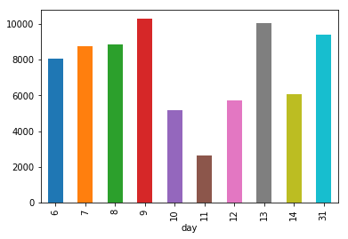

```python
df["day"] = df["day"].astype("datetime64")
df["day"].groupby(df["day"].dt.day).count().plot(kind="bar")
```

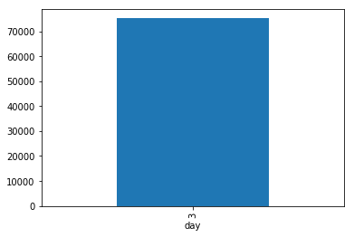

```python
df["day"].groupby(df["day"].dt.month).count().plot(kind="bar")
```

- All the data collected on March 2017, and only distribute in 6th-14th and 31st
- 31st is a wrong data, should be eliminated from the dataset

```python
df = df[df.day != "2017-03-31"]
```

Check missing data and propose possible missing data imputation

```python
df.info()
```

```
<class 'pandas.core.frame.DataFrame'>
Int64Index: 65673 entries, 0 to 75090
Data columns (total 47 columns):
browser                65673 non-null object
browser_v              65673 non-null object
ch                     32335 non-null object
day                    65673 non-null datetime64[ns]
dist_id                65673 non-null object
event                  65673 non-null object
from_url               982 non-null object
ip                     65673 non-null object
isMsg                  469 non-null object
isSuccess              791 non-null object
is_fd                  65673 non-null object
is_ft                  65673 non-null object
latest_ch              8537 non-null object
latest_r               64862 non-null object
latest_rh              64862 non-null object
latest_utm_campaign    39903 non-null object
latest_utm_content     38763 non-null object
latest_utm_m           39691 non-null object
latest_utm_s           40583 non-null object
latest_utm_t           39095 non-null object
model                  65673 non-null object
name                   15170 non-null object
nocache                65673 non-null object
os                     65673 non-null object
os_version             65673 non-null object
page                   11716 non-null object
pageP                  16490 non-null float64
pageS                  16720 non-null float64
pageUrl                30356 non-null object
refer_Host             32335 non-null object
referrHostUrl          469 non-null object
referrer               32334 non-null object
referrerUrl            469 non-null object
requestBtn             4271 non-null object
result                 1163 non-null object
screen_h               65673 non-null float64
screen_r               63046 non-null object
screen_rh              63039 non-null object
screen_w               65673 non-null float64
session_p              62766 non-null object
siteUrl                469 non-null object
site_url               982 non-null object
time                   65673 non-null int64
title                  32620 non-null object
tp                     65673 non-null object
url                    32598 non-null object
url_path               32620 non-null object
dtypes: datetime64[ns](1), float64(4), int64(1), object(41)
memory usage: 24.1+ MB
```

```python
df.isnull().sum()
```

```
browser                    0
browser_v                  0
ch                     33338
day                        0
dist_id                    0
event                      0
from_url               64691
ip                         0
isMsg                  65204
isSuccess              64882
is_fd                      0
is_ft                      0
latest_ch              57136
latest_r                 811
latest_rh                811
latest_utm_campaign    25770
latest_utm_content     26910
latest_utm_m           25982
latest_utm_s           25090
latest_utm_t           26578
model                      0
name                   50503
nocache                    0
os                         0
os_version                 0
page                   53957
pageP                  49183
pageS                  48953
pageUrl                35317
refer_Host             33338
referrHostUrl          65204
referrer               33339
referrerUrl            65204
requestBtn             61402
result                 64510
screen_h                   0
screen_r                2627
screen_rh               2634
screen_w                   0
session_p               2907
siteUrl                65204
site_url               64691
time                       0
title                  33053
tp                         0
url                    33075
url_path               33053
dtype: int64
```

The rows with "profile_set_once" were exactly the mistake 31st dates that were deleted (9419 rows) Features that have null value only at "profile_set_once" type: browser, browser_v, event, ip, is_fd, is_ft, model, os, os_version, screen_h, screen_w if we consider event, all these features including time, dist_id might be useful

### Conversion Rate (the percentage of users who take a desired action) Analyses

```python
df['event'].value_counts()
```

```
$pageview                32620
btnClick                 13866
index_leave              10394
demo_leave                3411
about_leave               1032
courses_leave              906
formSubmit                 791
courses_play_leave         747
click_send_cellphone       600
verify_cellphone_code      563
clickSubmit                513
page_close                 230
Name: event, dtype: int64
```

```python
nall = df.dist_id.nunique()
nall
```

```
11708
```

```python
nview = df_view.dist_id.nunique()
nview
```

```
11587
```

```python
nileave = df_ileave.dist_id.nunique()
nileave
```

```
6946
```

```python
nclick = df_btnclick.dist_id.nunique()
nclick
```

```
4501
```

```python
ndleave = df_dleave.dist_id.nunique()
ndleave
```

```
1436
```

```python
naleave = df_aleave.dist_id.nunique()
naleave
```

```
712
```

```python
ncleave = df_cleave.dist_id.nunique()
ncleave
```

```
692
```

```python
npleave = df_playleave.dist_id.nunique()
npleave
```

```
370
```

```python
nsend = df_send.dist_id.nunique()
nsend
```

```
501
```

```python
nverify = df_verify.dist_id.nunique()
nverify
```

```
472
```

```python
df_verify['result'].describe()
```

```
count     563
unique      3
top        正确
freq      528
Name: result, dtype: object
```

```python
df_verify[df_verify['result']=='正确'].dist_id.nunique()
```

```
471
```

Only one user from 472 users has wrong verification code, and never has correct verification code

```python
nform = df_form.dist_id.nunique()
nform
```

```
497
```

```python
nsubmit = df_submit.dist_id.nunique()
nsubmit
```

```
461
```

```python
nclose = df_close.dist_id.nunique()
nclose
```

```
97
```

```python
print("conversation rate of click send cellphone:")
print(nsend/nall)
```

```
conversation rate of click send cellphone:
0.04279125384352579
```

```python
print("conversation rate of verify cellphone code:")
print(nverify/nall)
```

```
conversation rate of verify cellphone code:
0.040314314998291766
```

The conversation rate from verify cellphone code to form submit increase: it is not neccessary to send verification code for form submit

```python
print("conversation rate of form submit:")
print(nform/nall)
```

```
conversation rate of form submit:
0.04244960710625213
```

```python
print("conversation rate of click submit:")
print(nsubmit/nall)
```

```
conversation rate of click submit:
0.0393747864707892
```

```python
print("conversation rate of demo leave:")
print(ndleave/nall)
```

```
conversation rate of demo leave:
0.12265117868124359
```

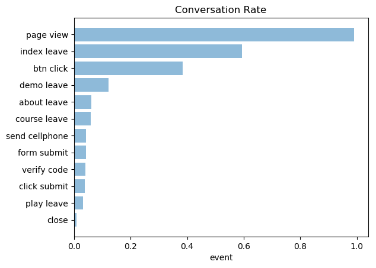

```python
import matplotlib.pyplot as plt; plt.rcdefaults()
import numpy as np
import matplotlib.pyplot as plt

objects = ('close','play leave','click submit','verify code','form submit','send cellphone', 'course leave',
           'about leave', 'demo leave', 'btn click', 'index leave','page view')
y_pos = np.arange(len(objects))
performance = [nclose/nall,npleave/nall,nsubmit/nall,nverify/nall,nform/nall,nsend/nall,ncleave/nall,
               naleave/nall,ndleave/nall,nclick/nall,nileave/nall,nview/nall]

plt.barh(y_pos, performance, align='center', alpha=0.5)
plt.yticks(y_pos, objects)
plt.xlabel('event')
plt.title('Conversation Rate')
plt.savefig('conversationrate.png',bbox_inches="tight",dpi=500)
plt.show()
```

The key factors that bottleneck the conversion rate is sign up/send celpphone verification

We can also look into why users view the page but never click

```python
#create a new data frame to check the user read page but do not click
df_vtc = df_view[~df_view.dist_id.isin(df_btnclick.dist_id)]
```

```python
df_vtc['dist_id'].describe()
```

```
count                                         9441
unique                                        7088
top       651397ce6ca369703bfa0f67342058c26cc1f4b9
freq                                            32
Name: dist_id, dtype: object
```

Among the user viewd page but do not click: most user only view once and never click

```python
print(df_vtc.title.value_counts(dropna=False))
```

```
神策数据 | Sensors Data - 国内领先的用户行为分析产品                                                                                                                                                                                                                                                                         …
介绍 · Sensors Analytics 使用手册                                                                                                                                                                                                                                                                                 …
神策分析|Sensors Analytics-帮你实现数据驱动－demo                                                                                                                                                                                                                                                                        …
神策分析|Sensors Analytics-帮你实现数据驱动－B轮融资发布会                                                                                                                                                                                                                                                                     …
神策分析|Sensors Analytics-帮你实现数据驱动-视频列表                                                                                                                                                                                                                                                                        …
神策分析|Sensors Analytics-帮你实现数据驱动－产品                                                                                                                                                                                                                                                                          …
数据模型 · Sensors Analytics 使用手册                                                                                                                                                                                                                                                                               …
JavaScript SDK · Sensors Analytics 使用手册                                                                                                                                                                                                                                                                     …
可视化埋点 · Sensors Analytics 使用手册                                                                                                                                                                                                                                                                              …
神策分析|Sensors Analytics-帮你实现数据驱动-网址构建工具                                                                                                                                                                                                                                                                      …
weixin://private/setresult/SCENE_FETCHQUEUE&eyJmdW5jIjoibG9nIiwicGFyYW1zIjp7Im1zZyI6Il9ydW5PbjNyZEFwaUxp…      93
事件分析 · Sensors Analytics 使用手册                                                                                                                                                                                                                                                                               …
Android SDK · Sensors Analytics 使用手册                                                                                                                                                                                                                                                                        …
惠州网站建设|惠州网站设计|惠州网站制作|网站设计-微斯诺科技                                                                                                                                                                                                                                                                             …
数据接入 · Sensors Analytics 使用手册                                                                                                                                                                                                                                                                               …
神策分析|Sensors Analytics-帮你实现数据驱动－关于                                                                                                                                                                                                                                                                          …
数据格式 · Sensors Analytics 使用手册                                                                                                                                                                                                                                                                               …
如何准确的标识用户 · Sensors Analytics 使用手册                                                                                                                                                                                                                                                                          …
```

[output cut: 44 more lines]

```python
df_view['dist_id'].describe()
```

```
count                                        32620
unique                                       11587
top       08ba9b365da9b395ab2a03ed1a76b97e01716a39
freq                                           152
Name: dist_id, dtype: object
```

```python
print(df_view.title.value_counts(dropna=False))
```

```
神策数据 | Sensors Data - 国内领先的用户行为分析产品                                                                                                                                                                                                                                                                         …
神策分析|Sensors Analytics-帮你实现数据驱动－demo                                                                                                                                                                                                                                                                        …
介绍 · Sensors Analytics 使用手册                                                                                                                                                                                                                                                                                 …
神策分析|Sensors Analytics-帮你实现数据驱动－产品                                                                                                                                                                                                                                                                          …
神策分析|Sensors Analytics-帮你实现数据驱动－B轮融资发布会                                                                                                                                                                                                                                                                     …
神策分析|Sensors Analytics-帮你实现数据驱动－关于                                                                                                                                                                                                                                                                          …
神策分析|Sensors Analytics-帮你实现数据驱动-视频列表                                                                                                                                                                                                                                                                        …
神策分析|Sensors Analytics-帮你实现数据驱动－视频播放                                                                                                                                                                                                                                                                        …
数据模型 · Sensors Analytics 使用手册                                                                                                                                                                                                                                                                               …
JavaScript SDK · Sensors Analytics 使用手册                                                                                                                                                                                                                                                                     …
事件分析 · Sensors Analytics 使用手册                                                                                                                                                                                                                                                                               …
数据格式 · Sensors Analytics 使用手册                                                                                                                                                                                                                                                                               …
可视化埋点 · Sensors Analytics 使用手册                                                                                                                                                                                                                                                                              …
神策分析|Sensors Analytics-帮你实现数据驱动-网址构建工具                                                                                                                                                                                                                                                                      …
weixin://private/setresult/SCENE_FETCHQUEUE&eyJmdW5jIjoibG9nIiwicGFyYW1zIjp7Im1zZyI6Il9ydW5PbjNyZEFwaUxp…      142
数据接入 · Sensors Analytics 使用手册                                                                                                                                                                                                                                                                               …
Android SDK · Sensors Analytics 使用手册                                                                                                                                                                                                                                                                        …
电商类产品 · Sensors Analytics 使用手册                                                                                                                                                                                                                                                                              …
```

[output cut: 44 more lines]

Compare the view data frame and view but not click dataframe: Most users stpped at the main page, people seems to have much interest in demo and product than B round of financing conference

Possible useful feature: session_r, session_rh, session_page_url, pageStayTime, pagePosition, pageUrl, latest_utm_s, latest_utm_s, latest_utm_t

```python
df.session_p.value_counts(dropna=True)
```

```
https://www.sensorsdata.cn/                                                                                                                                                                                                                                                                                 …
https://www.sensorsdata.cn/?utm_source=baidu&utm_medium=cpc&utm_term=%E7%A5%9E%E7%AD%96&utm_content=%E5%93%81%E7%89%8C%2D%E7%A5%9E%E7%AD%96&utm_campaign=%E5%93%81%E7%89%8C%E8%AF%8D                                                                                                                        …
https://www.sensorsdata.cn/?utm_source=baidu&utm_medium=cpc&utm_term=%E7%94%A8%E6%88%B7%E7%94%BB%E5%83%8F&utm_content=%E9%80%9A%E7%94%A8%2D%E7%94%A8%E6%88%B7%E7%94%BB%E5%83%8F&utm_campaign=%E9%80%9A%E7%94%A8%E8%AF%8D                                                                                    …
https://sensorsdata.cn/                                                                                                                                                                                                                                                                                     …
https://www.sensorsdata.cn/?utm_source=baidu&utm_medium=cpc&utm_term=%E7%A5%9E%E7%AD%96%E6%95%B0%E6%8D%AE&utm_content=%E5%93%81%E7%89%8C%2D%E7%A5%9E%E7%AD%96&utm_campaign=%E5%93%81%E7%89%8C%E8%AF%8D                                                                                                      …
https://www.sensorsdata.cn/demo.html                                                                                                                                                                                                                                                                        …
https://www.sensorsdata.cn/index.html                                                                                                                                                                                                                                                                       …
https://www.sensorsdata.cn/?utm_source=sogou&utm_medium=mcpc&utm_term=%e6%95%b0%e6%8d%ae%e5%88%86%e6%9e%90&utm_content=%e9%80%9a%e7%94%a8-%e6%95%b0%e6%8d%ae%e5%88%86%e6%9e%90&utm_campaign=S-%e9%80%9a%e7%94%a8%e8%af%8d                                                                                   …
https://www.sensorsdata.cn/?utm_source=baidu&utm_medium=mfeed&utm_term=%E9%A6%96%E9%A1%B5-%E9%80%9A%E7%94%A8%E8%AF%8D-%E4%B8%89%E5%9B%BE-%E5%9B%BE1&utm_content=%E9%80%9A%E7%94%A8%E8%AF%8D-%E4%B8%89%E5%9B%BE&utm_campaign=%E9%A6%96%E9%A1%B5                                                              …
https://www.sensorsdata.cn/?utm_source=baidu&utm_medium=cpc&utm_term=%E7%94%A8%E6%88%B7%E5%88%86%E6%9E%90&utm_content=%E9%80%9A%E7%94%A8%2D%E7%94%A8%E6%88%B7%E5%88%86%E6%9E%90&utm_campaign=%E9%80%9A%E7%94%A8%E8%AF%8D                                                                                    …
https://www.sensorsdata.cn/?utm_source=baidu&utm_medium=cpc&utm_term=%E7%94%B5%E5%AD%90%E5%95%86%E5%8A%A1%E6%95%B0%E6%8D%AE&utm_content=%E9%80%9A%E7%94%A8%2D%E7%94%B5%E5%95%86%E8%BF%90%E8%90%A5&utm_campaign=%E9%80%9A%E7%94%A8%E8%AF%8D                                                                  …
https://www.sensorsdata.cn/?utm_source=baidu&utm_medium=cpc&utm_term=%E7%A5%9E%E7%AD%96%E5%88%86%E6%9E%90&utm_content=%E5%93%81%E7%89%8C%2D%E7%A5%9E%E7%AD%96&utm_campaign=%E5%93%81%E7%89%8C%E8%AF%8D                                                                                                      …
https://www.sensorsdata.cn/?utm_source=baidu&utm_medium=cpc&utm_term=%E5%A4%A7%E6%95%B0%E6%8D%AE%E5%88%86%E6%9E%90&utm_content=%E9%80%9A%E7%94%A8%2D%E6%95%B0%E6%8D%AE%E5%88%86%E6%9E%90&utm_campaign=%E9%80%9A%E7%94%A8%E8%AF%8D                                                                           …
https://sensorsdata.cn/demo.html                                                                                                                                                                                                                                                                            …
https://www.sensorsdata.cn/?utm_source=baidu&utm_medium=cpc&utm_term=%E7%BD%91%E7%AB%99%E8%BF%90%E8%90%A5%E6%95%B0%E6%8D%AE%E5%88%86%E6%9E%90&utm_content=%E9%80%9A%E7%94%A8%2D%E6%95%B0%E6%8D%AE%E5%88%86%E6%9E%90%2D%E8%BF%90%E8%90%A5&utm_campaign=%E9%80%9A%E7%94%A8%E8%AF%8D                           …
https://www.sensorsdata.cn/?utm_source=baidu&utm_medium=cpc&utm_term=%E4%BA%A7%E5%93%81%E6%95%B0%E6%8D%AE%E5%88%86%E6%9E%90&utm_content=%E9%80%9A%E7%94%A8%2D%E6%95%B0%E6%8D%AE%E5%88%86%E6%9E%90&utm_campaign=%E9%80%9A%E7%94%A8%E8%AF%8D                                                                  …
https://www.sensorsdata.cn/?utm_source=baidu&utm_medium=cpc&utm_term=%E7%BD%91%E7%AB%99%E6%95%B0%E6%8D%AE%E7%BB%9F%E8%AE%A1&utm_content=%E9%80%9A%E7%94%A8%2D%E6%95%B0%E6%8D%AE%E7%BB%9F%E8%AE%A1&utm_campaign=%E9%80%9A%E7%94%A8%E8%AF%8D                                                                  …
https://www.sensorsdata.cn/?utm_source=baidu&utm_medium=cpc&utm_term=%E6%95%B0%E6%8D%AE%E5%88%86%E6%9E%90&utm_content=%E9%80%9A%E7%94%A8%2D%E6%95%B0%E6%8D%AE%E5%88%86%E6%9E%90&utm_campaign=%E9%80%9A%E7%94%A8%E8%AF%8D                                                                                    …
```

[output cut: 44 more lines]

```python
df.screen_r.value_counts(dropna=True)
```

```
https://www.baidu.com/baidu.php                                                                                                                                                                             24908
                                                                                                                                                                                                            16034
https://www.baidu.com/link                                                                                                                                                                                   4998
https://www.baidu.com/s                                                                                                                                                                                      1919
https://www.google.com.hk/                                                                                                                                                                                    907
https://www.google.com/                                                                                                                                                                                       783
http://36kr.com/                                                                                                                                                                                              654
https://www.sensorsdata.cn/                                                                                                                                                                                   371
https://sensorsdata.cn/                                                                                                                                                                                       328
https://www.google.co.jp/                                                                                                                                                                                     266
https://www.sensorsdata.cn/manual/                                                                                                                                                                            200
http://www.sensorsdata.cn/                                                                                                                                                                                    155
https://www.sensorsdata.cn/manual/use_feature_video.html                                                                                                                                                      113
http://www.itjuzi.com/company/16088                                                                                                                                                                           108
https://www.sensorsdata.cn/manual/js_sdk.html                                                                                                                                                                 104
https://link.zhihu.com/?target=https%3A//www.sensorsdata.cn                                                                                                                                                    98
https://www.sensorsdata.cn/manual/event_ana.html                                                                                                                                                               89
http://www.baidu.com/baidu.php?sc.7aTK00jwDwyKypmLhdEg8w50FJ0BMPOYV4r5HF1rrlnp7z0Di6zsomBfv6LjpPDYiHWM4m_9M06nuxWX5vctX9jotLfXoLKi6xRFseEIG1o5bLoVe9aVB_yqlzaYy4cXr7qShDjDMz62rAxRlUMUgPJ08rCD4IDXszL4h-       79
https://link.zhihu.com/?target=https%3A//sensorsdata.cn/                                                                                                                                                       77
https://www.sensorsdata.cn/manual/java_sdk.html                                                                                                                                                                77
https://m.baidu.com/?from=844b&vit=fps                                                                                                                                                                         76
https://www.sensorsdata.cn/demo.html                                                                                                                                                                           74
https://www.sogou.com/link?url=DSOYnZeCC_reF_V0215oSdRkvO5tusgbxcLO2TQn7Ac.&query=%E7%A5%9E%E7%AD%96%E6%95%B0%E6%8D%AE                                                                                         74
http://www.baidu.com/link?url=cqJ-HumjNapy4uRvaPvhHq05o4UMeVX_T3jLa0rkymicU1ZegoRzBQd8Or6cD1h4&wd=&eqid=f18597fa000314990000000658c261fc                                                                       70
https://www.baidu.com/                                                                                                                                                                                         70
http://www.woshipm.com/pmd/314444.html                                                                                                                                                                         70
https://www.sensorsdata.cn/manual/query.html                                                                                                                                                                   70
```

[output cut: 35 more lines]

```python
df.screen_rh.value_counts(dropna=True)
```

```
www.baidu.com                             33510
                                          16028
www.sensorsdata.cn                         2047
www.sogou.com                              1743
m.baidu.com                                1467
36kr.com                                   1453
www.google.com.hk                           926
www.google.com                              817
www.so.com                                  578
sensorsdata.cn                              569
link.zhihu.com                              447
www.google.co.jp                            252
cn.bing.com                                 250
m.sogou.com                                 214
wap.sogou.com                               199
www.woshipm.com                             142
image.baidu.com                             117
class.sanjieke.cn                           112
www.itjuzi.com                              108
passport.36kr.com                            78
googleads.g.doubleclick.net                  76
wenku.baidu.com                              72
youxuan.baidu.com                            63
www.sanjieke.cn                              56
www.google.com.ph                            55
www.mulumu.com                               54
qiye.aliyun.com                              54
zhidao.baidu.com                             54
mp.weixinbridge.com                          53
zhengbangchuangyi.cloud.sensorsdata.cn       49
                                          ...
www.tianyancha.com                            4
rong.36kr.com                                 3
hao.199it.com                                 3
wap.baidu.com                                 3
www.jiuzhilan.com                             3
vincentt.baijia.baidu.com                     3
ch.cloud.sensorsdata.cn                       3
www.3lian.com                                 3
h5.wps.cn                                     2
uc.36kr.com                                   2
www.xfz.cn                                    2
dp.g.doubleclick.net                          2
ad.bytedance.net                              2
www.google.co.kr                              2
datadang.com                                  2
huaban.com                                    2
geek.csdn.net                                 2
sd.int.jumei.com                              2
sensors.ymt360.com                            2
bohui.cloud.sensorsdata.cn                    2
data.gotokeep.com                             2
duckduckgo.com                                1
sas.foneshare.cn                              1
m.sp.sm.cn                                    1
data.corp.36kr.com                            1
haomaiyi.cloud.sensorsdata.cn                 1
lnkd.in                                       1
cache.baiducontent.com                        1
www.imgeek.org                                1
www.google.co.zm                              1
Name: screen_rh, Length: 139, dtype: int64
```

session_page_url extract referrer data to session_r, and further clean the data to session_rh. We can see how the session_r/session_rh classify as empty

```python
df['session_p'].loc[df['screen_r'] == '']
```

```
2                          https://sensorsdata.cn/?ch=demo
3                          https://sensorsdata.cn/?ch=demo
4                          https://sensorsdata.cn/?ch=demo
8                          https://sensorsdata.cn/?ch=demo
15                    https://www.sensorsdata.cn/demo.html
16                    https://www.sensorsdata.cn/demo.html
17                         https://sensorsdata.cn/?ch=demo
23                         https://sensorsdata.cn/?ch=demo
25                         https://sensorsdata.cn/?ch=demo
31                    https://www.sensorsdata.cn/demo.html
32                         https://sensorsdata.cn/?ch=demo
33                    https://www.sensorsdata.cn/demo.html
34                    https://www.sensorsdata.cn/demo.html
35                    https://www.sensorsdata.cn/demo.html
38                    https://www.sensorsdata.cn/demo.html
```

[output cut: 47 more lines]

most of empty session_r and session_rh are directly from sensordata website, a few have utm_s: baidu

```python
df.latest_utm_s.value_counts(dropna=False)
```

```
baidu                 36085
NaN                   25090
sogou                  1943
sales4c                 441
wechat                  432
google                  393
admin                   374
sanjieke.cn             273
next.36kr.com            68
sunwenliang              65
mulumu.com               57
tianguang                56
liuyaozhou               38
liujinbo1                38
gaoxiaoqing              34
zhihu                    34
hao.caibaojian.com       33
sina                     31
admin10                  22
toutiao.io               20
analytics_test           15
shenyulong               15
guohongyao               11
demo                     11
linhuiyong               10
yupan                     9
email                     9
sunjiaqian                7
qiye.36kr.com             7
gongxinrong               4
zhoushunzhou              4
hzcaibin                  4
23h5                      4
diaopeng                  4
liquantao                 3
wangcheng                 3
zhangyuejiao              2
lijiong                   2
prd_luzhaobo              2
xueting                   2
dichang                   2
Jeremy                    2
sidashidai                2
liyizi                    2
xiangc                    1
xiuxin                    1
jonson                    1
zhangji                   1
wangxuelin                1
quqianshun                1
lingchentian              1
huangkan                  1
lul                       1
fuyu                      1
Name: latest_utm_s, dtype: int64
```

latest_utm_s has 25090 empty, they come from sesordata website directly considering the number, we can bin this feature as baidu and not baidu

```python
df.latest_utm_m.value_counts(dropna=False)
```

```
cpc                   34623
NaN                   25982
mcpc                   3255
mfeed                   934
default                 538
answer                  133
banner                   67
hao.caibaojian.com       33
production               27
sidonghui                24
toutiao.io               20
referral                 15
youjian                   8
lixinya                   6
customer_m                5
sidashidai                2
edm                       1
Name: latest_utm_m, dtype: int64
```

```python
df.latest_utm_t.value_counts(dropna=False)
```

```
NaN             26578
神策               7529
用户画像             5349
神策数据             3393
数据分析             1419
首页-通用词-三图-图1      934
大数据分析             813
用户分析              812
神策分析              677
电子商务数据            662
聚类分析              511
网站运营数据分析          506
网站数据统计            494
产品数据分析            489
用户画像分析            455
旅游大数据             411
app数据             406
数据分析系统            345
客户画像              310
app数据分析           293
用户行为              288
app分析             283
数据挖掘              279
数据可视化             250
日志分析系统            248
大数据应用             246
电商数据分析            243
数据分析公司            242
数据统计平台            231
数据分析平台            227
                ...
运营商数据分析             2
网站流量统计              2
跨屏分析                2
数据分析工具有哪些           2
精益运营                2
用户画像建模              2
用户日志分析              2
银行用户画像标签            2
用户行为挖掘              2
数据统计分析系统            2
产业大数据分析             2
电商精细化运营             2
分析运营数据              2
多数据整合               2
营运数据分析              2
数据分析法方法             2
金融精准营销              2
国内大数据分析             2
访客数据分析              2
用户行为日志分析            2
广告效果监测系统            2
神测数据                2
用户画像平台              2
网站用户行为分析            2
数据收集分析系统            2
提高转化率               1
游戏用户留存率             1
互联网行业数据分析           1
数据多维分析              1
私有化部署               1
Name: latest_utm_t, Length: 297, dtype: int64
```

```python
df.latest_utm_campaign.value_counts(dropna=False)
```

```
NaN                            25770
通用词                            22180
品牌词                            11929
S-通用词                           1917
神策-移动推广                          998
首页                               934
G-通用词                            391
用户行为                             285
caroline                         133
gamedemo                         133
vtrack                           118
ebizdemo                         109
test_fll_gxq_zgq                  73
financedemo                       72
spring                            68
xingshulin_standalone             65
golddemo                          60
凤巢头条                              57
数据分析                              44
trial                             34
jiedaibao-standalone              29
about                             27
皇冠子链                              26
李彦敏                               24
edudemo                           22
courses                           21
用户画像                              16
ch                                13
yeshen-cluster                    11
zhibodemo                         10
ivymobi                           10
salestest                          8
zhangjunfeng                       8
iranshao                           7
vipkid-standalone                  7
sagreen                            6
36kr_standalone                    5
caicheng-standalone                5
huangbaoche-standalone             5
%E9%80%9A%E7%94%A8%E8%AF%8D        4
wangba-standalone                  4
qiyukf                             4
jrq-standalone                     4
test-ztx-jsl-fjj                   3
8win_standalone                    3
jumei-cluster                      2
数据采集                               2
ymt-cluster                        2
通用词\                               2
flowerplus                         2
keep-cluster                       2
qingchengfit                       2
yiwu-standalone                    2
kupai-standalone                   2
fxiaoke-cluster                    1
haomaiyi                           1
bqbianli-standalone                1
Name: latest_utm_campaign, dtype: int64
```

```python
df.latest_utm_content.value_counts(dropna=False)
```

```
NaN                                                                          26910
品牌-神策                                                                        11678
通用-用户画像                                                                       5529
通用-数据分析                                                                       3136
通用-数据分析-产品                                                                    1403
通用-数据分析-行业                                                                    1242
通用-数据分析-运营                                                                    1042
通用-用户分析                                                                        983
通用词-三图                                                                         934
通用-APP运营                                                                       913
通用词-M                                                                          795
通用-电商运营                                                                        730
通用-用户行为分析                                                                      696
通用-用户画像-产品                                                                     684
通用-数据处理                                                                        658
通用-数据可视化                                                                       653
通用-数据统计                                                                        589
通用-用户留存                                                                        487
通用-网站运营                                                                        455
通用-大数据-行业                                                                      407
通用-数据分析-公司                                                                     388
通用-大数据-其他                                                                      384
通用-用户画像-功能                                                                     331
通用-数据系统                                                                        323
品牌-神策-英文                                                                       315
通用-用户行为分析-行业                                                                   306
通用-多维分析                                                                        250
通用-数据统计-产品                                                                     244
通用-埋点                                                                          222
通用-数据分析-互联网                                                                    212
                                                                             ...
通用-用户留存-提升                                                                     142
通用-数据分析法                                                                       134
通用-大数据-方案                                                                      102
通用-用户分析-产品                                                                     102
通用-数据分析-方案                                                                      92
通用-数据指标                                                                         84
通用-数据分析-电商                                                                      64
通用-增长黑客                                                                         57
通用-可视化分析                                                                        53
品牌-神策-产品词                                                                       52
通用-用户分群                                                                         37
right                                                                           36
top                                                                             31
通用-大数据-公司                                                                       31
通用-数据驱动                                                                         28
通用-访客分析                                                                         26
通用-渠道追踪                                                                         21
通用-个性化营销                                                                        18
通用-数据仓库                                                                         18
通用-精准营销                                                                         16
通用-大数据-产品                                                                       14
通用-用户细分                                                                          8
品牌-神策-拼音                                                                         8
通用-用户画像-应用                                                                       5
%E9%80%9A%E7%%20...                                                              5
品牌-                                                                              5
%E9%80%9A%E7%94%A8-%E7%94%A8%E6%88%B7%E8%A1%8C%E4%B8%BA%E5%88%86%E6%9E%90        4
通用-跨屏分析                                                                          2
通用-用户行为分析-产品                                                                     2
通用-转化优化                                                                          1
Name: latest_utm_content, Length: 69, dtype: int64
```

```python
df['source'] = df['latest_utm_s'].fillna('sensordata')
```

```python
df.source[~df.source.isin(['baidu','sensordata'])] = 'others'
```

```python
df.source.value_counts(dropna=False)
```

```
baidu         36085
sensordata    25090
others         4498
Name: source, dtype: int64
```

```python
df['medium'] = df['latest_utm_m'].fillna('ukmedium')
```

```python
df.medium[~df.medium.isin(['cpc','ukmedium'])] = 'others'
```

```python
df.medium.value_counts(dropna=False)
```

```
cpc         34623
ukmedium    25982
others       5068
Name: medium, dtype: int64
```

```python
df['content'] = df['latest_utm_content'].fillna('ukcontent')
```

```python
df.content[df.content.str.contains('数据')] = 'data'
df.content[~df.content.isin(['data','ukcontent'])] = 'others'
```

```python
df.content.value_counts(dropna=False)
```

```
ukcontent    26910
others       26828
data         11935
Name: content, dtype: int64
```

```python
df.pageUrl.value_counts(dropna=True)
```

```
https://www.sensorsdata.cn/demo.html                                                                                                                                                                                                                                                  4377
https://www.sensorsdata.cn/                                                                                                                                                                                                                                                           3857
https://www.sensorsdata.cn/index.html                                                                                                                                                                                                                                                 1832
https://www.sensorsdata.cn/product.html                                                                                                                                                                                                                                               1640
https://www.sensorsdata.cn/?utm_source=baidu&utm_medium=cpc&utm_term=%E7%94%A8%E6%88%B7%E7%94%BB%E5%83%8F&utm_content=%E9%80%9A%E7%94%A8%2D%E7%94%A8%E6%88%B7%E7%94%BB%E5%83%8F&utm_campaign=%E9%80%9A%E7%94%A8%E8%AF%8D                                                              1526
https://www.sensorsdata.cn/about.html                                                                                                                                                                                                                                                 1485
https://sensorsdata.cn/                                                                                                                                                                                                                                                               1318
https://www.sensorsdata.cn/?utm_source=baidu&utm_medium=cpc&utm_term=%E7%A5%9E%E7%AD%96&utm_content=%E5%93%81%E7%89%8C%2D%E7%A5%9E%E7%AD%96&utm_campaign=%E5%93%81%E7%89%8C%E8%AF%8D                                                                                                  1235
https://sensorsdata.cn/demo.html                                                                                                                                                                                                                                                      1222
https://www.sensorsdata.cn/courses/                                                                                                                                                                                                                                                   1063
https://sensorsdata.cn/?ch=demo                                                                                                                                                                                                                                                        948
https://www.sensorsdata.cn/?utm_source=baidu&utm_medium=cpc&utm_term=%E7%A5%9E%E7%AD%96%E6%95%B0%E6%8D%AE&utm_content=%E5%93%81%E7%89%8C%2D%E7%A5%9E%E7%AD%96&utm_campaign=%E5%93%81%E7%89%8C%E8%AF%8D                                                                                 544
https://sensorsdata.cn/index.html                                                                                                                                                                                                                                                      430
https://sensorsdata.cn/about.html                                                                                                                                                                                                                                                      361
https://www.sensorsdata.cn/?utm_source=sogou&utm_medium=mcpc&utm_term=%e6%95%b0%e6%8d%ae%e5%88%86%e6%9e%90&utm_content=%e9%80%9a%e7%94%a8-%e6%95%b0%e6%8d%ae%e5%88%86%e6%9e%90&utm_campaign=S-%e9%80%9a%e7%94%a8%e8%af%8d                                                              303
https://sensorsdata.cn/product.html                                                                                                                                                                                                                                                    291
https://www.sensorsdata.cn/courses/index.html                                                                                                                                                                                                                                          272
https://www.sensorsdata.cn/?utm_source=baidu&utm_medium=cpc&utm_term=%E7%94%A8%E6%88%B7%E5%88%86%E6%9E%90&utm_content=%E9%80%9A%E7%94%A8%2D%E7%94%A8%E6%88%B7%E5%88%86%E6%9E%90&utm_campaign=%E9%80%9A%E7%94%A8%E8%AF%8D                                                               271
```

[output cut: 44 more lines]

```python
df.pageP.value_counts(dropna=False)
```

```
NaN     49183
 1.0    10679
 2.0     4032
 3.0      898
 4.0      881
Name: pageP, dtype: int64
```

```python
df['event'].loc[df['pageP'] == 4.0].value_counts(dropna=False)
```

```
index_leave    881
Name: event, dtype: int64
```

PageUrl and PageP has the same information: which specific page interested

```python
df.pageS.describe()
```

```
count    1.672000e+04
mean     6.681742e+03
std      5.343221e+04
min      3.300000e-02
25%      5.390750e+00
50%      2.057950e+01
75%      2.261860e+02
max      2.918014e+06
Name: pageS, dtype: float64
```

Total number of rows in btnclick: 13866; posible features with not too much null values. latest_r 78 latest_rh 78 latest_utm_campaign 5227 latest_utm_content 5451 latest_utm_m 5263 latest_utm_s 5069 latest_utm_t 5383 page 2150 pageUrl 0 screen_h 0 screen_r 0 screen_rh 0 screen_w 0 session_p 2

```python
df_btnclick.page.value_counts(dropna=False)
```

```
index            7964
demo             2242
NaN              2150
about             816
courses_index     694
Name: page, dtype: int64
```

```python
df_btnclick.loc[df_btnclick['page']=='demo'].dist_id.nunique()
```

```
787
```

```python
df_btnclick.name.value_counts(dropna=False)
```

```
request     2967
demo        2783
document    2067
product     1942
b-round     1245
about        925
blog         803
viedo        550
logo         508
mail          76
Name: name, dtype: int64
```

```python
df_btnclick.loc[df_btnclick['name']=='demo'].dist_id.nunique()
```

```
1268
```

on the demo page, there were around 500 users did not click on anything or continue

btnclick has 2242 demo in page and 2783 demo in name, while demo leave has 3411 items

```python
df_cts = df_btnclick[~df_btnclick.dist_id.isin(df_send.dist_id)].loc[df_btnclick['page']=='demo']
```

```python
df_cts.dist_id.nunique()
```

```
479
```

```python
df_stc = df_send[~df_send.dist_id.isin(df_btnclick.loc[df_btnclick['page']=='demo'].dist_id)]
```

```python
df_stc.dist_id.nunique()
```

```
193
```

```python
df_dts = df_dleave[~df_dleave.dist_id.isin(df_send.dist_id)]
```

```python
df_dts.dist_id.nunique()
```

```
1027
```

```python
df_std = df_send[~df_send.dist_id.isin(df_dleave.dist_id)]
```

```python
df_std.dist_id.nunique()
```

```
92
```

1027 users go to demo but do not register 92 users register but never go to demo

First, some people don't click on demo page: have no interst first Second, some click on demo but decide not to continue to register

Total number of rows in page view: 32620

```python
df_view.url.value_counts(dropna=True)
```

```
https://www.sensorsdata.cn/demo.html                                                                                                                                                                                                                                                3231
https://www.sensorsdata.cn/                                                                                                                                                                                                                                                         2810
https://www.sensorsdata.cn/product.html                                                                                                                                                                                                                                             2118
https://www.sensorsdata.cn/manual/                                                                                                                                                                                                                                                  1921
https://www.sensorsdata.cn/b-round.html                                                                                                                                                                                                                                             1287
https://www.sensorsdata.cn/index.html                                                                                                                                                                                                                                               1164
https://www.sensorsdata.cn/?utm_source=baidu&utm_medium=cpc&utm_term=%E7%94%A8%E6%88%B7%E7%94%BB%E5%83%8F&utm_content=%E9%80%9A%E7%94%A8%2D%E7%94%A8%E6%88%B7%E7%94%BB%E5%83%8F&utm_campaign=%E9%80%9A%E7%94%A8%E8%AF%8D                                                            1025
https://www.sensorsdata.cn/about.html                                                                                                                                                                                                                                                950
https://sensorsdata.cn/                                                                                                                                                                                                                                                              927
https://sensorsdata.cn/demo.html                                                                                                                                                                                                                                                     886
https://www.sensorsdata.cn/manual/index.html                                                                                                                                                                                                                                         800
https://www.sensorsdata.cn/courses/                                                                                                                                                                                                                                                  724
https://www.sensorsdata.cn/?utm_source=baidu&utm_medium=cpc&utm_term=%E7%A5%9E%E7%AD%96&utm_content=%E5%93%81%E7%89%8C%2D%E7%A5%9E%E7%AD%96&utm_campaign=%E5%93%81%E7%89%8C%E8%AF%8D                                                                                                 667
https://www.sensorsdata.cn/?utm_source=baidu&utm_medium=mfeed&utm_term=%E9%A6%96%E9%A1%B5-%E9%80%9A%E7%94%A8%E8%AF%8D-%E4%B8%89%E5%9B%BE-%E5%9B%BE1&utm_content=%E9%80%9A%E7%94%A8%E8%AF%8D-%E4%B8%89%E5%9B%BE&utm_campaign=%E9%A6%96%E9%A1%B5                                       603
https://sensorsdata.cn/b-round.html                                                                                                                                                                                                                                                  453
https://sensorsdata.cn/?ch=demo                                                                                                                                                                                                                                                      448
https://sensorsdata.cn/manual/                                                                                                                                                                                                                                                       399
https://sensorsdata.cn/product.html                                                                                                                                                                                                                                                  346
```

[output cut: 44 more lines]

```python
df_view.url_path.value_counts(dropna=True)
```

```
/                                                                                                                                                                     12243
/demo.html                                                                                                                                                             4183
/manual/                                                                                                                                                               2634
/product.html                                                                                                                                                          2473
/b-round.html                                                                                                                                                          1907
/index.html                                                                                                                                                            1474
/about.html                                                                                                                                                            1186
/manual/index.html                                                                                                                                                      917
/courses/                                                                                                                                                               900
/courses/play.html                                                                                                                                                      832
/manual/data_model.html                                                                                                                                                 232
/courses/index.html                                                                                                                                                     231
/manual/js_sdk.html                                                                                                                                                     216
/manual/data_schema.html                                                                                                                                                156
/manual/event_ana.html                                                                                                                                                  151
/tools/url_create.html                                                                                                                                                  147
/manual/vtrack_intro.html                                                                                                                                               147
/manual/android_sdk.html                                                                                                                                                131
/manual/ios_sdk.html                                                                                                                                                    120
/manual/eb_case.html                                                                                                                                                    119
/manual/data_import.html                                                                                                                                                112
/tools/code_auto/                                                                                                                                                       110
/manual/use_steps.html                                                                                                                                                  101
/D:/xampp/htdocs/%E5%BE%AE%E6%96%AF%E8%AF%BA%E7%A7%91%E6%8A%80%E6%9C%89%E9%99%90%E5%85%AC%E5%8F%B8%E5%AE%98%E7%BD%91/%E7%A8%8B%E5%BA%8F/data.html                        98
/manual/user_identify.html                                                                                                                                               98
/manual/funnel.html                                                                                                                                                      76
/manual/user_segmentation.html                                                                                                                                           76
```

[output cut: 35 more lines]

```python
df_view.title.value_counts(dropna=True)
```

```
神策数据 | Sensors Data - 国内领先的用户行为分析产品                                                                                                                                                                                                                                                                         …
神策分析|Sensors Analytics-帮你实现数据驱动－demo                                                                                                                                                                                                                                                                        …
介绍 · Sensors Analytics 使用手册                                                                                                                                                                                                                                                                                 …
神策分析|Sensors Analytics-帮你实现数据驱动－产品                                                                                                                                                                                                                                                                          …
神策分析|Sensors Analytics-帮你实现数据驱动－B轮融资发布会                                                                                                                                                                                                                                                                     …
神策分析|Sensors Analytics-帮你实现数据驱动－关于                                                                                                                                                                                                                                                                          …
神策分析|Sensors Analytics-帮你实现数据驱动-视频列表                                                                                                                                                                                                                                                                        …
神策分析|Sensors Analytics-帮你实现数据驱动－视频播放                                                                                                                                                                                                                                                                        …
数据模型 · Sensors Analytics 使用手册                                                                                                                                                                                                                                                                               …
JavaScript SDK · Sensors Analytics 使用手册                                                                                                                                                                                                                                                                     …
事件分析 · Sensors Analytics 使用手册                                                                                                                                                                                                                                                                               …
数据格式 · Sensors Analytics 使用手册                                                                                                                                                                                                                                                                               …
可视化埋点 · Sensors Analytics 使用手册                                                                                                                                                                                                                                                                              …
神策分析|Sensors Analytics-帮你实现数据驱动-网址构建工具                                                                                                                                                                                                                                                                      …
weixin://private/setresult/SCENE_FETCHQUEUE&eyJmdW5jIjoibG9nIiwicGFyYW1zIjp7Im1zZyI6Il9ydW5PbjNyZEFwaUxp…      142
数据接入 · Sensors Analytics 使用手册                                                                                                                                                                                                                                                                               …
Android SDK · Sensors Analytics 使用手册                                                                                                                                                                                                                                                                        …
电商类产品 · Sensors Analytics 使用手册                                                                                                                                                                                                                                                                              …
```

[output cut: 44 more lines]

```python
df_view.ch.value_counts()[df_view['ch'].value_counts()>10]
```

```
www.sensorsdata.cn                        12634
                                           7091
www.baidu.com                              6284
sensorsdata.cn                             2764
m.baidu.com                                 816
www.sogou.com                               352
36kr.com                                    208
www.google.com.hk                           166
www.google.com                              156
localhost                                   154
m.sogou.com                                 147
link.zhihu.com                              146
wap.sogou.com                               144
image.baidu.com                              67
www.so.com                                   67
www.google.co.jp                             48
ebizdemo.cloud.sensorsdata.cn                41
googleads.g.doubleclick.net                  41
www.woshipm.com                              34
cn.bing.com                                  33
zhidao.baidu.com                             23
data.isoubu.com                              21
sensors.ishansong.com                        21
sensorswww.cloud.sensorsdata.cn              20
youxuan.baidu.com                            20
zhengbangchuangyi.cloud.sensorsdata.cn       20
data.corp.36kr.com                           17
wapbaike.baidu.com                           17
so.m.sm.cn                                   16
class.sanjieke.cn                            15
wenku.baidu.com                              15
sensors.jiedaibao.com                        15
www.itjuzi.com                               15
tongji.yeshen.com                            14
www.google.com.tw                            14
www.sanjieke.cn                              14
mp.weixinbridge.com                          14
c.tieba.baidu.com                            14
yandex.ru                                    12
saasdemo.cloud.sensorsdata.cn                12
cpro.baidu.com                               11
sd.int.jumei.com                             11
Name: ch, dtype: int64
```

```python
df_view.refer_Host.value_counts()[df_view['refer_Host'].value_counts()>10]
```

```
www.sensorsdata.cn                        12634
                                           7091
www.baidu.com                              6284
sensorsdata.cn                             2764
m.baidu.com                                 816
www.sogou.com                               352
36kr.com                                    208
www.google.com.hk                           166
www.google.com                              156
localhost                                   154
m.sogou.com                                 147
link.zhihu.com                              146
wap.sogou.com                               144
image.baidu.com                              67
www.so.com                                   67
www.google.co.jp                             48
ebizdemo.cloud.sensorsdata.cn                41
googleads.g.doubleclick.net                  41
www.woshipm.com                              34
cn.bing.com                                  33
zhidao.baidu.com                             23
data.isoubu.com                              21
sensors.ishansong.com                        21
sensorswww.cloud.sensorsdata.cn              20
youxuan.baidu.com                            20
zhengbangchuangyi.cloud.sensorsdata.cn       20
data.corp.36kr.com                           17
wapbaike.baidu.com                           17
so.m.sm.cn                                   16
class.sanjieke.cn                            15
wenku.baidu.com                              15
sensors.jiedaibao.com                        15
www.itjuzi.com                               15
tongji.yeshen.com                            14
www.google.com.tw                            14
www.sanjieke.cn                              14
mp.weixinbridge.com                          14
c.tieba.baidu.com                            14
yandex.ru                                    12
saasdemo.cloud.sensorsdata.cn                12
cpro.baidu.com                               11
sd.int.jumei.com                             11
Name: refer_Host, dtype: int64
```

refer_Host same as ch

```python
df_view.screen_rh.value_counts()[df_view['screen_rh'].value_counts()>10]
```

```
www.baidu.com                             14770
                                           8361
www.sensorsdata.cn                         1054
m.baidu.com                                 994
36kr.com                                    790
www.sogou.com                               735
www.google.com.hk                           445
www.google.com                              372
sensorsdata.cn                              293
www.so.com                                  234
link.zhihu.com                              189
m.sogou.com                                 165
wap.sogou.com                               150
cn.bing.com                                 122
www.google.co.jp                            122
www.woshipm.com                              64
image.baidu.com                              61
class.sanjieke.cn                            50
www.itjuzi.com                               49
googleads.g.doubleclick.net                  43
wenku.baidu.com                              28
passport.36kr.com                            27
zhengbangchuangyi.cloud.sensorsdata.cn       27
www.sanjieke.cn                              26
mp.weixinbridge.com                          25
zhidao.baidu.com                             24
so.m.sm.cn                                   23
www.mulumu.com                               22
youxuan.baidu.com                            22
www.google.com.tw                            21
www.google.com.sg                            20
mail.alibaba-inc.com                         20
www.google.com.ph                            20
www.linear.vc                                19
a.youdao.com                                 18
www.google.com.au                            18
wapbaike.baidu.com                           17
mail.qq.com                                  17
qiye.aliyun.com                              16
saasdemo.cloud.sensorsdata.cn                14
ebizdemo.cloud.sensorsdata.cn                14
c.tieba.baidu.com                            14
next.36kr.com                                14
www.oneapm.com                               14
hippter.com                                  12
www.digitaling.com                           12
cpro.baidu.com                               12
google.gg-g.org                              12
www.google.nl                                11
www.tongdao.io                               11
www.qichacha.com                             11
wisd.sogou.com                               11
Name: screen_rh, dtype: int64
```

Session referrer host similar to refer_Host and ch, but more null values Same as the analysis on btnclick and page view, use latest_utm

- Analysis on the reason for demo leave
- Note that we can find utm_source on other data frame to see if we can find not null values

```python
# If you do NOT have geoip2 library installed
# Uncomment and run the code below

#import sys
#!{sys.executable} -m pip install geoip2
```

```python
import geoip2.database
```

```python
# read library from local file
reader = geoip2.database.Reader('./data/GeoLite2-Country_20180501/GeoLite2-Country.mmdb')
```

```python
# example usage of geoip2
response = reader.country('219.135.131.99')
```

```python
response.country.iso_code
```

```
'CN'
```

ip address has 8296 unrecognized value

```python
# Define CN: user has ip address in China
#df['CN'] = df['ip'].apply(lambda row: reader.country(row).country.iso_code == 'CN')
CN=[]
for i in range(len(df['ip'])):
    try:
        CN.append ((reader.country(df.loc[i,'ip']).country.iso_code == 'CN') * 1)
    except:
        CN.append(0)
```

```python
df['CN'] = CN
```

```python
df.CN.value_counts(dropna=True)
```

```
1    56401
0     9272
Name: CN, dtype: int64
```

```python
import geoip2.database
# read library from local file
reader = geoip2.database.Reader('./data/GeoLite2-City_20180501/GeoLite2-City.mmdb')
```

```python
CT=[]
for i in range(len(df['ip'])):
    try:
        CT.append (reader.city(df.loc[i,'ip']).city.name)
    except:
        CT.append('0')
```

```python
df['CT'] = CT
```

```python
df['CT'].value_counts(dropna=False)
```

```
Beijing           20185
0                  8296
Shanghai           7196
Guangzhou          7063
Hangzhou           4183
Shenzhen           3736
Chengdu            1973
Nanjing            1817
Haidian            1558
Wuhan              1184
NaN                1027
Tianjin             569
Hefei               463
Shenyang            375
Zhengzhou           297
Jinan               284
Fuzhou              278
Changsha            275
Suzhou              260
Wenzhou             239
Chongqing           236
Hebei               195
Shantou             175
Jinghe              166
Xi'an               162
Xiamen              148
Foshan              129
Zhuhai              124
Dongguan            122
Ürümqi              114
                  ...
London                1
Shiqi                 1
Jiaozuo               1
São Paulo             1
Ordos                 1
Hoest                 1
Kunyang               1
Cheung Sha Wan        1
Dongyang              1
Selden                1
Jiekou                1
Nchelenge             1
Korolev               1
Redwood City          1
Kazan’                1
Chiang Mai            1
Danyang               1
Huai Khwang           1
Hippolytushoef        1
Pesaro                1
Zhangjiakou           1
Wafangdian            1
Neutral Bay           1
Pizhou                1
Burnaby               1
Depok                 1
Kuala Lumpur          1
Montpellier           1
Walnut                1
Guildford             1
Name: CT, Length: 242, dtype: int64
```

```python
df['weekend'] = ((df.day == '2017-03-11') | (df.day == '2017-03-12')) * 1
```

```python
# define sign up column with users have form submit behavior
ind = df.dist_id.isin(df_form.dist_id) *1
```

```python
df['signup'] = ind.tolist()
```

```python
df_select = df.copy()
```

```python
df_select['freq'] = df_select.groupby('dist_id')['dist_id'].transform('count')
```

```python
df_select.weekend.value_counts(dropna=True)
```

```
0    57297
1     8376
Name: weekend, dtype: int64
```

```python
df_select.signup.value_counts(dropna=True)
```

```
0    53029
1    12644
Name: signup, dtype: int64
```

```python
df_select['freq'].describe()
```

```
count    65673.000000
mean        25.265467
std         36.783402
min          1.000000
25%          5.000000
50%         13.000000
75%         30.000000
max        254.000000
Name: freq, dtype: float64
```

```python
df_select.isnull().sum()
```

```
browser                    0
browser_v                  0
ch                     33338
day                        0
dist_id                    0
event                      0
from_url               64691
ip                         0
isMsg                  65204
isSuccess              64882
is_fd                      0
is_ft                      0
latest_ch              57136
latest_r                 811
latest_rh                811
latest_utm_campaign    25770
latest_utm_content     26910
latest_utm_m           25982
latest_utm_s           25090
latest_utm_t           26578
model                      0
name                   50503
nocache                    0
os                         0
os_version                 0
page                   53957
pageP                  49183
pageS                  48953
pageUrl                35317
refer_Host             33338
referrHostUrl          65204
referrer               33339
referrerUrl            65204
requestBtn             61402
result                 64510
screen_h                   0
screen_r                2627
screen_rh               2634
screen_w                   0
session_p               2907
siteUrl                65204
site_url               64691
time                       0
title                  33053
tp                         0
url                    33075
url_path               33053
source                     0
medium                     0
content                    0
CN                         0
CT                      1027
weekend                    0
signup                     0
freq                       0
dtype: int64
```

```python
selected_columns = [u'dist_id',u'event',u'browser',u'browser_v',u'day', u'is_fd',
                    u'is_ft', u'ip', u'latest_utm_s',u'latest_utm_m',u'latest_utm_content',u'model', u'os',
                    u'os_version',u'pageS', u'pageP',u'time', u'CN', u'CT',u'source', u'medium',u'content',
                    u'weekend',u'freq',u'signup']
```

```python
cleaned_data_csv = 'data/cleaned_data.csv'
df_select[selected_columns].to_csv(cleaned_data_csv, index=False)
```

```python
df_select[['dist_id','latest_utm_s']].tail(10)
```

|  | dist_id | latest_utm_s |
| --- | --- | --- |
| 75079 | 215110e7713ef7435524bf321fa894e411338c40 | None |
| 75080 | 215110e7713ef7435524bf321fa894e411338c40 | None |
| 75081 | 215110e7713ef7435524bf321fa894e411338c40 | None |
| 75082 | 215110e7713ef7435524bf321fa894e411338c40 | None |
| 75083 | 215110e7713ef7435524bf321fa894e411338c40 | None |
| 75084 | 215110e7713ef7435524bf321fa894e411338c40 | None |
| 75085 | 215110e7713ef7435524bf321fa894e411338c40 | None |
| 75086 | 215110e7713ef7435524bf321fa894e411338c40 | None |
| 75088 | 1b384ff8574084ef4a7356a8cd0c36350286e576 | None |
| 75090 | 3b23eacd700848ff085ec5877df695456bfe6bb3 | baidu |

Try to check if we can use the first time source for anlysis, seems to be the same

```
1    514
0     86
Name: CN, dtype: int64
```

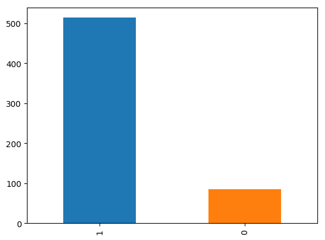

```python
df_select['CN'].loc[df_select['event'] == 'click_send_cellphone'].value_counts(dropna=False).plot.bar()
df_select['CN'].loc[df_select['event'] == 'click_send_cellphone'].value_counts(dropna=False)
```

```
1    441
0     72
Name: CN, dtype: int64
```

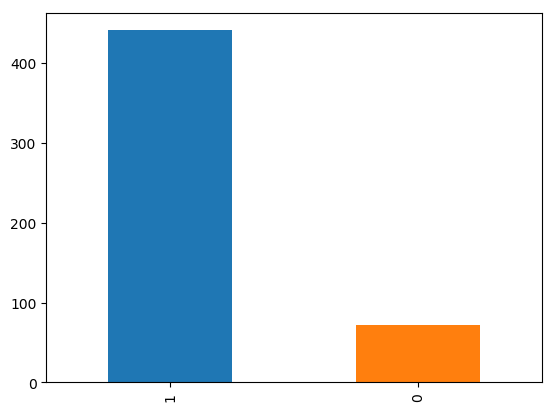

```python
df_select['CN'].loc[df_select['event'] == 'clickSubmit'].value_counts(dropna=False).plot.bar()
df_select['CN'].loc[df_select['event'] == 'clickSubmit'].value_counts(dropna=False)
```

```
1    493
0     70
Name: CN, dtype: int64
```

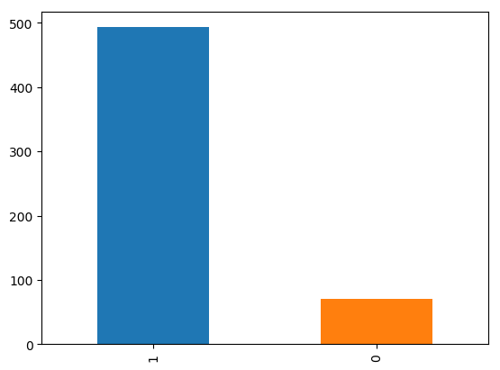

```python
df_select['CN'].loc[df_select['event'] == 'verify_cellphone_code'].value_counts(dropna=False).plot.bar()
df_select['CN'].loc[df_select['event'] == 'verify_cellphone_code'].value_counts(dropna=False)
```

Ip address in or not in China, did not influence sign up rate. Users interested in this website can even sign up or use Chinese cellphone number even in abroad.